# Creating the `FunctionalClust` R package

### Create a dataset

```r
#data <- read.csv("../data/combined_proteindata_loadingnorm_imputed_rownorm_20240617.csv" , row.names = 1)
#label_data <- read.csv("../data/annotationsforlopit_20240813.csv")
#full_data <- left_join(tibble::rownames_to_column(data),label_data,by=c("rowname"="protein_id"))

yeast2018 <- read.csv("../../data/yeast2018.csv",row.names = 1)
hirst2018 <- read.csv("../../data/hirst2018.csv",row.names = 1)
moloneyTbBSF <- read.csv("../../data/moloneyTbBSF.csv",row.names = 1)
lopitdcU2OS2018 <- read.csv("../../data/lopitdcU2OS2018.csv",row.names = 1)
E14TG2aR <- read.csv("../../data/E14TG2aR.csv",row.names = 1)
Loay2024 <- read.csv("../../data/Loay2024.csv",row.names = 1)
```

Now, let’s send this off to the package:

```r
usethis::use_data(yeast2018,hirst2018,moloneyTbBSF,lopitdcU2OS2018,E14TG2aR,Loay2024)
```

```
## ✔ Adding R to 'Depends' field in DESCRIPTION.
```

```
## ✔ Creating 'data/'.
```

```
## ✔ Setting 'LazyData' to "true" in 'DESCRIPTION'.
```

```
## ✔ Saving "yeast2018", "hirst2018", "moloneyTbBSF", "lopitdcU2OS2018",
##   "E14TG2aR", and "Loay2024" to "data/yeast2018.rda", "data/hirst2018.rda",
##   "data/moloneyTbBSF.rda", "data/lopitdcU2OS2018.rda", "data/E14TG2aR.rda", and
##   "data/Loay2024.rda".
```

```
## ☐ Document your data (see <https://r-pkgs.org/data.html>).
```

### Choosing the best hyper-parameters

```r
#' Cross validation to choose the best h_0
#'
#' @param data Data in matrix form(n * p). Can be the data result from prepare_data
#' @param label Label set. Can be the label result from prepare_data
#' @param grid Grid values of bandwidth h
#' @param num_clust Number of cluster. If not specified, will equal to number of distinct label
#' @param bandwidth Smooth bandwidth
#' @param max_iter Maximum iteration
#' @param min_gap Minimum difference of likelihood
#' @param nrep Number of repetitions
#' @return A list with three elements:
#'           • all_lost – a list contains all the lost at all grid
#'           • average_lost – average lost at all grid
#'           • best_h – the best bandwidth
#' @export
cv_functional_clust <- function(data , label , grid = seq(0.1,2.5,0.1), num_clust , max_iter = 1000, min_gap = 0.1, nrep = 10){
  cv_all <- vector("list", length(grid))
  for(i in 1:length(grid)){
    h <- grid[i]
    p <- dim(data)[2]

    cv <- rep(0,p)
    for(j in 1:p){
      res <- functional_cluster(data[,-j] ,label = label, num_clust = num_clust , bandwidth = h ,max_iter = max_iter , min_gap = min_gap ,nrep = nrep)

      # mu_hat_(-j)(j)
      mu_hat <- res$result$mu %*% gaussian_kernel(seq(1,p,1)[-j],j,h) / sum(gaussian_kernel(seq(1,p,1)[-j],j,h))
      # gamma*y_j
      mu_tru <- t(res$result$resp) %*% as.matrix(data[,j])/colSums(res$result$resp)
      # variance
      sigma_sq_tru <- diag(t(res$result$resp) %*% sweep(matrix(rep(c(data[,j]),8),ncol=8,byrow=FALSE), 2, mu_tru,"-")^2/colSums(res$result$resp))
      # error
      cv[j] <- sum((mu_hat-mu_tru)^2/sigma_sq_tru)
    }
    cv_all[[i]] <- cv
  }

  # a list contain number of grids' vectors. Each vector contain number of channels errors.
  return(list(all_lost = cv_all , average_lost = lapply(cv_all,mean), best_h = grid[which.min(lapply(cv_all,mean))]))
}
```

### Visualization

```r
#'
#' @param data Data
#' @param label Label
#' @param prediction Generate from prediction function
#' @export
visualize_res <- function(data,label,res){
  pred <- prediction(res)

  d.umap <- umap::umap(data,n_neighbors = 500, min_dist = 0.05,
                 verbose = T, n_epochs = 1000, n_components=2)
  scores <- data.frame(d.umap$layout)

  colnames(scores) <- c("x1","x2")
  data = data %>%
    cbind(scores) %>%
    cbind(pred)

  new_group <- paste0( "New", seq_len( length(unique(pred$predict_label)) - length(unique(label[,2])) ) )
  levels <- c(attr(label$label, "levels"), new_group)

  p1 <- data %>% ggplot() +
  geom_point(data = data[-label[,1],], # unlabeled
             aes(x = x1, y = x2), size=1, alpha = 0.1) +
  geom_point(data = data[label[,1],], # labeled
             aes(x = x1, y = x2, col = levels[label[,2]] ), size=1.5, alpha = 0.8) +
  theme_classic() +
  theme(legend.title = element_blank(),
        plot.subtitle = element_text(hjust = 0.5),
        panel.grid.major = element_line(color = "gray88", size = 0.2)
        ) +
  labs(subtitle = "Annotated data set")

  p2 <- data %>%
  ggplot() +
  geom_point(aes(x = x1, y = x2, col = levels[predict_label], size = prob) , alpha = .8) +
  scale_size(range = c(0.01, 1.5)) +
  labs(color = "", size = "Probability") +
  theme_classic() +
  theme(plot.subtitle = element_text(hjust = 0.5),
        legend.spacing.y = unit(0.05, 'cm'),
        legend.margin = margin(0, 0, 0, 0),
        panel.grid.major = element_line(color = "gray88", size = 0.2)
        ) +
  labs(subtitle = "Predictive groups")

  p1 / p2
}
```

Draw high probability bands

```r
#'
#' @param res Output from functional_cluster
#' @param alpha Alpha level, default is 0.05
#' @param label Label set, used to assign graph titles. Can be empty(default)
#'
#' @export
draw_hpb <- function(res, alpha = 0.05,label = NULL){
  K <- nrow(res$result$mu)
  p <- ncol(res$result$mu)

  if(!is.null(label)){
    group <- attr(label$label,"levels")
    if(K>length(group)){
      group <- c(group,paste0("New", 1: (K - length(group))))
    }
  }else{
    group <- paste0("Group",1:K)
  }

  for(i in 1:K){
    mean_line <- res$result$mu[i,]
    var_all <- res$result$sigma[i,]
    x <- seq(1,p)
    par(mgp = c(3, 0.5, 0))
    plot(x, t(mean_line), type = "l", ylim = c(0,1),lty = 1, lwd = 2, pch = 20, col = i,
         xlab = "", ylab = "",main = group[i])
    upper <- mean_line + qnorm(1 - (1-(1-alpha)^(1/11))/2,0,1) * var_all
    lower <- mean_line - qnorm(1 - (1-(1-alpha)^(1/11))/2,0,1) * var_all
    polygon(c(x, rev(x)), c(upper, rev(lower)), col = adjustcolor(i, alpha.f = 0.2), border = NA)

  }
}
```

### Testing

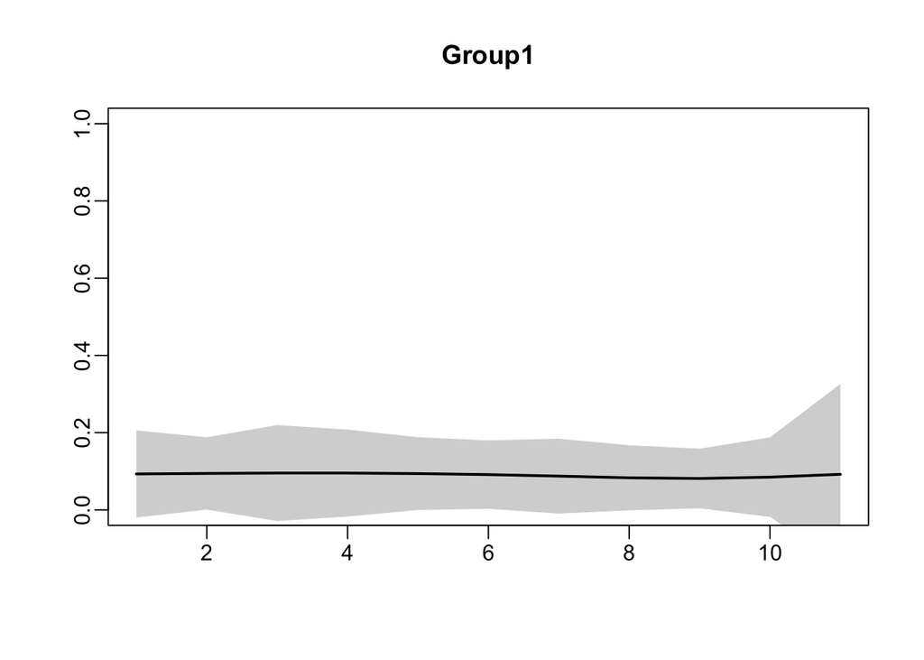

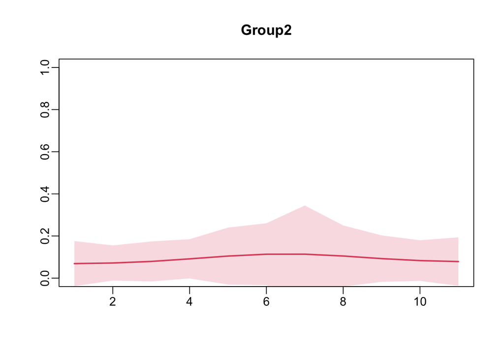

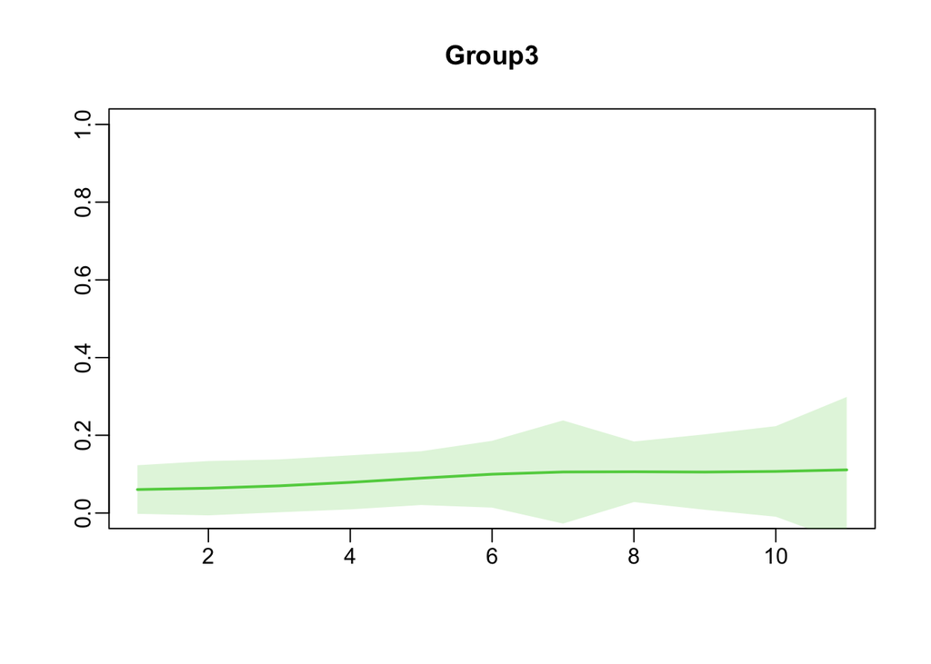

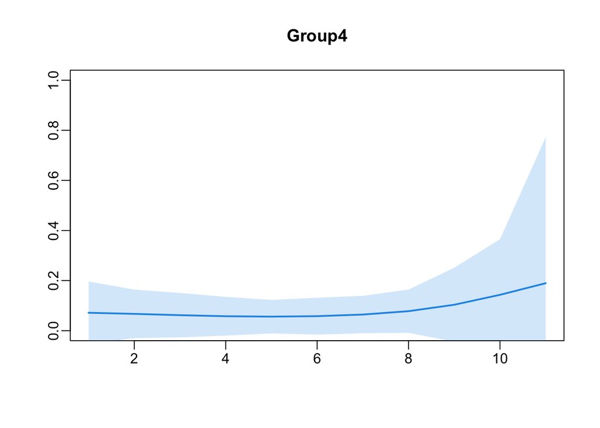

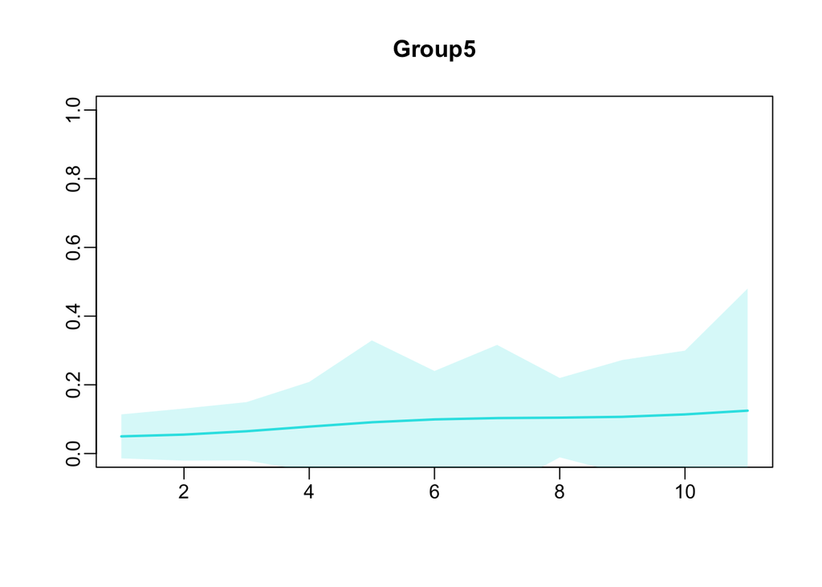

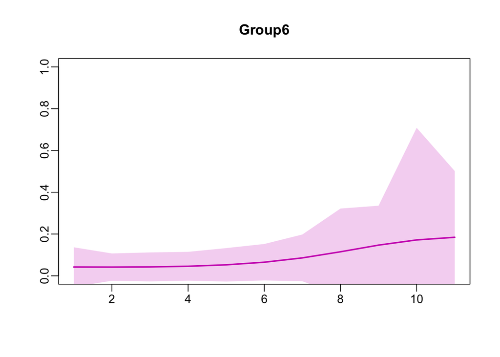

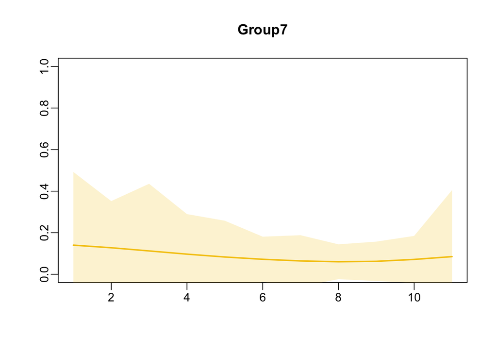

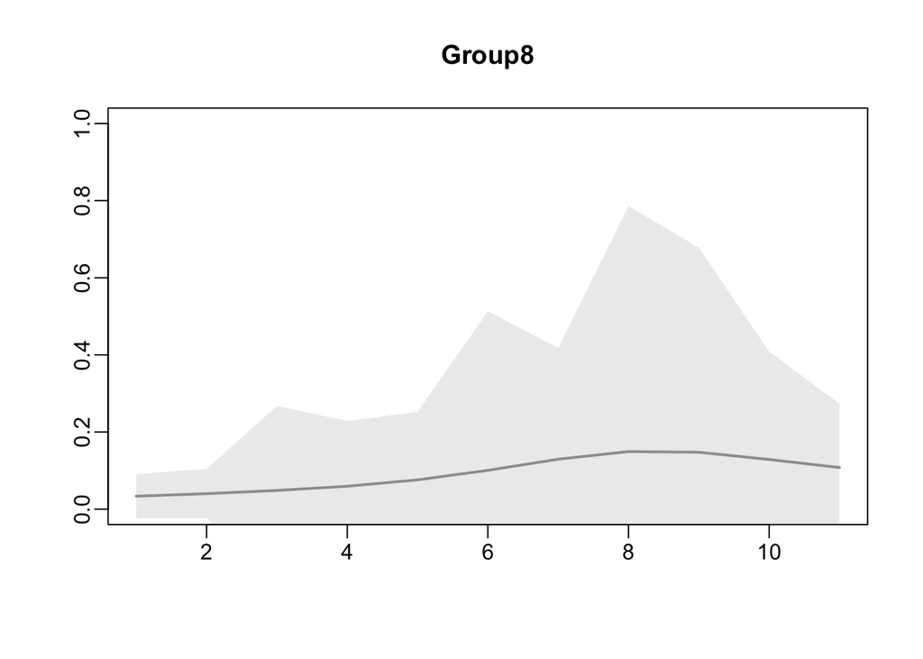

```r
#testthat::test_that("functional clustering work", {
#  testthat::expect_equal(say_hello("Jacob"), "Hello Jacob!")
#  testthat::test
#})
train_data <- prepare_data(Loay2024)
res <- functional_cluster(data = train_data$data, label = train_data$labels, num_clust = 8 , bandwidth = 1.5, max_iter = 1000, min_gap = 0.1, nrep = 10)

#cv_functional_clust(data = train_data$data, label = train_data$labels, grid = seq(1,1.5,0.1),num_clust=8,max_iter = 1000, min_gap = 0.1, nrep = 10)

#pre_res <- prediction(res$result$resp)

#visualize_res(data = train_data$data, label = train_data$labels , res = res)

draw_hpb(res, alpha = 0.05)
```

Code chunks that have one or more lines starting with `test_that(` (or `testthat::test_that(`) are added to the package as tests.

## Documenting the package and building

We finish by running commands that will document, build, and install the package. It may also be a good idea to check the package from within this file.

```r
litr::document() # <-- use instead of devtools::document()
```

[output not shown]

```r
devtools::build()
```

```
## ── R CMD build ─────────────────────────────────────────────────────────────────
## * checking for file ‘/Users/ziyuezheng/Documents/GitHub/UCSC/Research/protein_cluster/package/FunctionalClust/DESCRIPTION’ ... OK
## * preparing ‘FunctionalClust’:
## * checking DESCRIPTION meta-information ... OK
## * checking for LF line-endings in source and make files and shell scripts
## * checking for empty or unneeded directories
## * building ‘FunctionalClust_0.0.0.9000.tar.gz’
```

```
## [1] "/Users/ziyuezheng/Documents/GitHub/UCSC/Research/protein_cluster/package/FunctionalClust_0.0.0.9000.tar.gz"
```

```r
#devtools::install()
#devtools::check(document = FALSE)
```

### Add a README

Our README.Rmd lives in the `source-files` directory. As described [here](https://pkgdown.r-lib.org/reference/build_home.html#package-logo), if we have a hex sticker, we’ll add something like the following to the level-one header at the top of the README:

```
# withpkgdown: An Example Package <img src="man/figures/logo.png" align="right" height="139" />
```

We add `README.Rmd` to the package and then generate the `README.md` based on it:

```r
#litr::add_readme("../source-files/README.Rmd")
```

### Add a vignette

```r
#litr::add_vignettes("../source-files/using-package.Rmd")
```